# Entrega 1: Genetic Association Studies

Big Data en Biociències

Francesc Aguirre, 1398024

Gener de 2021

# 1. Objectiu

Trobar variants genètiques de susceptibilitat en la base de dades *asthma*.

# 2. Metodologia, anàlisi de dades i resultats

## 2.1 Obtenció de les dades i paquets

### 2.1.1 Paquets estadístics d’R

```r
library(SNPassoc)
library(magrittr)
library(FactoMineR)

library(rvest)
library(stringr)
library(tableHTML)
```

S’utilitzarà el paquet estadístic **SNPassoc** per facilitar l’anàlisi genètica, i el paquet **magrittr** per la creació de pipelines. El paquet **FactoMineR** pot ajudar a fer un càlcul ràpid de les components principals per l’ajust del model genètic, i **MASS** per la selecció de variables i histogrames.

També s’utilitzen algunes funcions de **purrr** per aplicar funcions similars al conjunt base apply. Els paquets **rvest** i **stringr** s’han fet servir per l’exercici suplementari de web scrapping que he proposat. **tableHTML** s’ha fet servir per afegir colors a la taula de resultats.

Qualsevol funció o codi R que no surti en aquest document es pot trobar a [github](https://github.com/cesc1/GAS-example) (secció ANNEX).

### 2.1.2 Taula de dades

```r
setwd("..")
root_path = getwd()

asthma <- read.table(paste0(root_path, "/data/asthma.txt"), header=TRUE)
asthma$caco <- factor(asthma$caco)
asthma$copd <- factor(asthma$copd)
source(paste0(root_path, "/code/GAS.R"))
```

S’han utilitzat les dades d’un estudi epidemiològic sobre l’asma, que conté 1578 individus agrupats en casos i controls. Es tenen 51 single-nucleotide polymorphisms (SNPs), a més del país, sexe, edat, bmi i nivell d’obstrucció pulmonar dels individus.

## 2.2 Anàlisi descriptiva no genètica

En aquesta primera anàlisi descriptiva de les variables no genètiques, es busca una visualització ràpida de la distribució de les variables. També s’intenta detectar possibles errors de mostreig que puguin crear biaix en el futur anàlisi.

### 2.2.1 Anàlisi univariant

Taula 1: Estadistics univariants no genètics

| Variable | Levels/Method | n | Percent/quartils |
| --- | --- | --- | --- |
| country | Australia | 127 | 8.0 |
|  | Belgium | 14 | 0.9 |
|  | Estonia | 6 | 0.4 |
|  | France | 219 | 13.9 |
|  | Germany | 154 | 9.8 |
|  | Norway | 177 | 11.2 |
|  | Spain | 377 | 23.9 |
|  | Sweden | 281 | 17.8 |
|  | Switzerland | 100 | 6.3 |
|  | UK | 123 | 7.8 |
| gender | Females | 789 | 50.0 |
|  | Males | 789 | 50.0 |
| age | mean | 1578 | (37.0, 42.9, 48.7) |
| bmi | median | 1566 | (22.7, 24.9, 27.7) |
| copd | 0 | 646 | 41.1 |
|  | 1 | 452 | 28.8 |
|  | 2 | 355 | 22.6 |
|  | 3 | 68 | 4.3 |
|  | 4 | 50 | 3.2 |
| caco | 0 | 1238 | 78.5 |
|  | 1 | 340 | 21.5 |

### 2.2.2 Anàlisi bivariant

Taula 2: Estadistics bivariants no genètics categorics, segons casos i controls d’asma

| Variable | Labels | 0 | 1 |
| --- | --- | --- | --- |
| country | Australia | 82 | 45 |
|  | Belgium | 0 | 14 |
|  | Estonia | 0 | 6 |
|  | France | 193 | 26 |
|  | Germany | 148 | 6 |
|  | Norway | 168 | 9 |
|  | Spain | 328 | 49 |
|  | Sweden | 181 | 100 |
|  | Switzerland | 71 | 29 |
|  | UK | 67 | 56 |
| gender | Females | 592 | 197 |
|  | Males | 646 | 143 |

La Taula 2 de contingència, es tenen els casos i controls d’asma, segons el país i el sexe. Es detecta que de Belgium i Estonia es tenen pocs individus, i només s’observen casos. També es tenen proporcions diferents de casos i controls segons el país. Això crea un problema si es vol utilitzar el país com a variable d’ajust. Com que els strats no estan equilibrats, els models logístics poden crear un biaix important. Per aquest motiu, s’exclourà el país com a variable d’ajust.

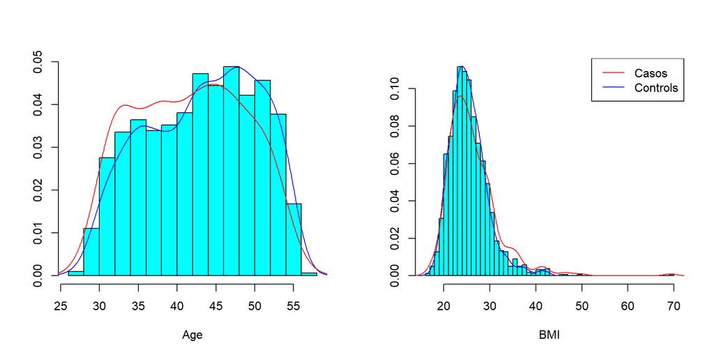

Gràfic 1: Plot univariant i bivariant de les variables numèriques

El gràfic 1 és la distribució mostral de les variables edat i bmi, i les línies de colors són les densitats per casos i controls. No es veuen majors diferències entre casos i controls. Es detecta una possible mixtura de normals en l’edat, i cua pesada per la dreta en el bmi (és d’esperar la cua en el bmi).

## 2.3 Control de qualitat

### 2.3.1 Data Cleaning

SNPs que continguin un nombre de valors perduts (individus) superior al 5%, s’eliminaran de l’anàlisi, ja que un nombre tan elevat de valors perduts podria esbiaixar els resultats.

S’ha creat la funció *remove_NA()* per aplicar aquest pas en una pipeline.

### 2.3.2 HWE Control

S’han comprobat les freqüències dels al·lels individuals amb les poblacionals, a partir del test de Hardy-Weinberg (HWE). SNPs amb un p-valor significatiu (menor que 0.05) dins de la distribució dels controls, s’eliminaran de l’anàlisi.

S’ha creat la funció *remove_HWE()* per aplicar aquest pas en una pipeline.

### 2.3.3 Aplicant pipeline

Utilitzar una pipeline per a transformacions d’un dataset ajuda a mantenir un ordre en aplicar les funcions, ajuda visualment i fa el codi fàcilment reproduïble i reutilitzable.

S’han aplicat les transformacions anteriors en l’ordre següent:

1. Transformem les dades en classe **snp**.
2. Eliminem els SNPs amb un nombre de valors perduts superiors al 5%.
3. Eliminem els SNPs que no compleixin el test de HWE estratificant per controls.

Inicialment es tenen 57 columnes en la taula de dades *asthma*.

```r
first_col_SNP <- 7

dat <- asthma %>%
  setupSNP(colSNPs = first_col_SNP:ncol(asthma), sep = "/") %>%
  remove_NA(maxPerc = 5) %>%
  remove_HWE(strat_name = "caco", reflevel = "0")

snp_names <- names(dat)[first_col_SNP:ncol(dat)] # s'agafen els noms dels SNPs
dim(dat)
```

```
## [1] 1578   49
```

Finalment es tenen 49 columnes en la nova taula de dades.

S’han eliminat 8 SNPs que no complien les condicions de qualitat proposades.

## 2.4 Selecció de variables no genètiques

### 2.4.1 Variables d’ajust

Per a triar les variables d’ajust en els nostres models genètics, una opció és fer-ho a partir de variables que sabem que influeixen a tenir asma. Algunes habituals són el sexe i l’edat.

En el nostre cas, no tenim una idea clara sobre quines variables poden influir. Es seguirà el següent procediment: De les variables suggerides en les dades *asthma*, es farà un procediment de selecció de variables pas a pas per saber per quines ajustar. S’utilitzarà el mètode *stepAIC* amb direcció = “both” de la llibreria **MASS**, que selecciona o exclou variables a partir de l’AIC que aportin al model.

Com s’ha comentat a la secció 2.2.2 d’anàlisi descriptiva, no s’utilitzarà la variable *països* perquè els strats no estan equilibrats.

```r
mod0 <- glm(caco ~ gender + age + bmi, family = binomial, data = dat)
mod1 <- MASS::stepAIC(mod0, trace = T)
```

```
## Start:  AIC=1580.42
## caco ~ gender + age + bmi
##
##          Df Deviance    AIC
## <none>        1572.4 1580.4
## - gender  1   1584.3 1590.3
## - bmi     1   1585.6 1591.6
## - age     1   1588.1 1594.1
```

Taula 3: Coeficients del model no genètic

|  | Estimate | Pr(>\|z\|) |
| --- | --- | --- |
| (Intercept) | -0.90 | 0.071 |
| genderMales | -0.43 | 0.001 |
| age | -0.03 | 0.000 |
| bmi | 0.05 | 0.000 |

Es selecciona el model complet, on totes les variables són significatives.

### 2.4.2 Components Principals

Quan es treballa amb diferents poblacions (strats), és important tenir en compte que hi pot haver diferències en les freqüències al·lèliques, segons l’strat.

Per resoldre aquest problema, a part d’ajustar per les variables no genètiques, es recomana ajustar per les primeres components principals del genotip codificat.

A tenir en compte:

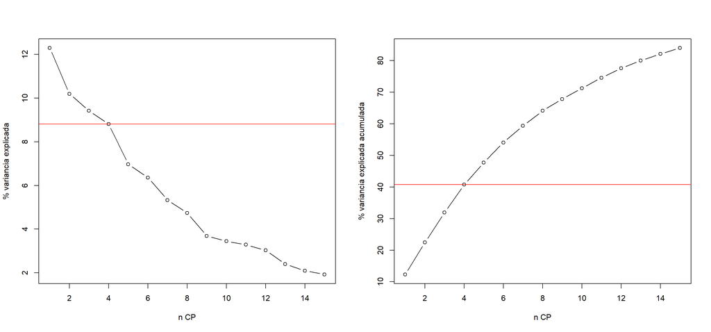

Grafic 2

```r
pca <- dat[, snp_names] %>%
  gen_to_num() %>%
  FactoMineR::PCA(ncp = 4, graph = F)

PC <- data.frame(matrix(nrow = nrow(dat), ncol = 4))
PC[complete.cases(dat[, snp_names]), ] <- pca$ind$coord
colnames(PC) <- paste0("PC", 1:4)
```

Per elegir el nombre de components, s’ha creat el Gràfic 2, fet a partir dels valors propis resultants (% variància explicada). En el gràfic de l’esquerra, es pot veure un colze després de la quarta component, i tot seguit s’estabilitza linealment (es veu un segon colze en la component 9). Això indica que elegir quatre components pot ser una bona opció. Les quatre components expliquen més del 40% de la variabilitat explicada pels SNPs. Per ajustar els models genètics, tenint en compte que estem en un estudi GAS amb poques dades, aquesta quantitat s’ha considerat apropiada.

## 2.5 Models d’associació genètica

Per cada SNP, s’han creat 3 models logístics: Dominant, Recessiu i log-Aditiu. Es seleccionarà el model amb el p-valor més baix dels 3.

Per investigar l’efecte que pot tenir ajustar per components principals, és interessant fer l’anàlisi ajustant pels 4 components principals, i després fer-lo sense aquest ajust, per veure les diferències en els resultats.

També, un cop calculats els p-valors, com que s’estan fent tests múltiples, s’ajustarà per la correcció de Benjamini-Hochberg.

S’ha creat la funció *associationAll()* per aplicar els models a tots els SNPs, i extreure els resultats en una taula.

```r
taula <- associationAll("caco ~ gender + age + bmi + PC$PC1 + PC$PC2 + PC$PC3 + PC$PC4",
               snpIDs = snp_names, data = dat)
colnames(taula)[3:5] <- paste(colnames(taula)[3:5], "PCA", sep = "_")

taula_noPCA <- associationAll("caco ~ gender + age + bmi",
               snpIDs = snp_names, data = dat) %>%
  extract(, c("OR", "P_value", "P_value_adj"))
colnames(taula_noPCA) <- paste0(colnames(taula_noPCA), "_NoPCA")

taula <- cbind(taula, taula_noPCA)
```

Ja tenim la taula amb els p-valors ajustats! Recordar que també s’han afegit els p-valors quan no s’ha ajustat per PCA, per comparar l’ajust de les components. La Taula 4 es pot trobar a la secció 2.7.

## 2.6 Cerca del Gen

Per fer l’anàlisi de xarxes de gens, s’ha de saber de quin gens provenen els SNPs més significatius.

Es tenen diferents opcions per obtenir aquesta informació:

1. Anar a [dbSNP](https://www.ncbi.nlm.nih.gov/snp/) i buscar aquesta informació manualment. És viable quan tenim una quantitat de SNPs significatius petita, com és el nostre cas.
2. Utilitzar **web scrapping**. Extreure la informació que volem manualment pot ser un procés repetitiu. Programar pot servir per automatitzar aquestes tasques.
3. Cerca directa a partir d’una base de dades que ja contingui aquesta informació. És una opció molt més ràpida que web scrapping, per quan tenim grans quantitats de dades (ej: Utilitzant SQL).

Ja que s’ha esmentat web scrapping com a opció, s’ha realitzat un exemple d’aquesta tècnica amb els SNPs de la nostra anàlisi per il·lustrar aquest procés.

Utilitzar web scrapping en el meu ordinador personal tarda al voltant d’1s/busqueda. Aquest temps depen de la connexió a internet que es tingui, capacitat computacional… És més ràpid que fer-ho manualment, però no es poden fer milers de cerques sense gastar hores de capacitat computacional en un ordinador personal. És ideal per tasques com, buscar informació de 200 snps, amb un temps d’entre 3 i 5 minuts.

```r
source(paste0(root_path, "/code/webScrappingSNP.R"))

data_web <- lapply(snp_names, function(snp_name){
  datanode <- load_ncbi_datanode(snp_name)
  chromosoma = extractCh(datanode)
  data.frame(Gene = extractGen(datanode),
             Ch = chromosoma$ch,
             Pos = chromosoma$pos)
}) %>%
  do.call(what = rbind)
taula_resultats <- cbind(taula, data_web)
```

Un dels SNPs no s’ha trobat, i particularment comença amb un prefix (hopo) diferent de la resta (rs).

## 2.7 Taula de resultats

Taula 4: Per cada SNP tenim l'identificador i el model utilitzat (model amb menor p-valor). També es té l'OR, el p-valor, el p-valor corregint per Benjamini-Hochberg, i les mateixes 3 columnes sense ajustar per components principals. Finalment es té informació univariant sobre l'SNP (gen, chromozoma, posició del cromosoma Mb). Tenir en compte que per els models no ajustats per PCA, el model type pot ser diferent al que s'indica.

| ID | Model_type | OR_PCA | P_value_PCA | P_value_adj_PCA | OR_NoPCA | P_value_NoPCA | P_value_adj_NoPCA | Gene | Ch | Pos |
| --- | --- | --- | --- | --- | --- | --- | --- | --- | --- | --- |
| rs324960 | Recessiu | 0.38 | 0.001 | 0.064 | 0.48 | 0.002 | 0.036 | NPSR1 | 7 | 34.76 |
| rs1422993 | Dominant | 1.45 | 0.008 | 0.165 | 1.38 | 0.011 | 0.152 | SPINK5 | 5 | 148.12 |
| rs10486657 | Additiu | 1.90 | 0.034 | 0.351 | 1.39 | 0.332 | 0.540 | NPSR1 | 7 | 34.76 |
| rs1419780 | Additiu | 1.80 | 0.051 | 0.351 | 1.57 | 0.168 | 0.540 | NPSR1 | 7 | 34.78 |
| rs324981 | Additiu | 0.61 | 0.053 | 0.351 | 0.81 | 0.021 | 0.229 | NPSR1 | 7 | 34.78 |
| rs184448 | Dominant | 1.57 | 0.056 | 0.351 | 1.64 | 0.001 | 0.030 | NPSR1 | 7 | 34.73 |
| rs512625 | Dominant | 0.78 | 0.065 | 0.351 | 0.82 | 0.109 | 0.467 | ADAM33 | 20 | 3.67 |
| rs714588 | Dominant | 1.38 | 0.065 | 0.351 | 1.10 | 0.478 | 0.662 | NPSR1-AS1 | 7 | 34.65 |
| rs324396 | Recessiu | 0.60 | 0.085 | 0.406 | 1.26 | 0.065 | 0.467 | NPSR1 | 7 | 34.75 |
| rs963218 | Additiu | 1.27 | 0.095 | 0.409 | 1.07 | 0.644 | 0.769 | NPSR1 | 7 | 34.67 |
| rs1419835 | Dominant | 1.33 | 0.105 | 0.409 | 0.78 | 0.414 | 0.614 | NPSR1 | 7 | 34.68 |
| rs898070 | Recessiu | 1.35 | 0.135 | 0.424 | 1.22 | 0.268 | 0.540 | NPSR1 | 7 | 34.66 |
| rs2303063 | Recessiu | 0.78 | 0.136 | 0.424 | 0.83 | 0.231 | 0.540 | SPINK5 | 5 | 148.10 |
| rs727162 | Additiu | 1.19 | 0.140 | 0.424 | 1.24 | 0.094 | 0.467 | NPSR1 | 7 | 34.83 |
| rs746710 | Recessiu | 1.36 | 0.148 | 0.424 | 1.12 | 0.209 | 0.540 | DPP10 | 2 | 114.45 |
| rs6084432 | Dominant | 1.23 | 0.162 | 0.429 | 1.26 | 0.088 | 0.467 | GFRA4 | 20 | 3.66 |
| rs11123242 | Dominant | 0.78 | 0.178 | 0.429 | 1.39 | 0.318 | 0.540 | NA | 2 | 114.42 |
| rs1430094 | Dominant | 1.32 | 0.180 | 0.429 | 1.23 | 0.107 | 0.467 | NA | 2 | 114.44 |
| rs1367179 | Dominant | 0.78 | 0.191 | 0.429 | 1.41 | 0.283 | 0.540 | NA | 2 | 114.42 |
| rs7332573 | Additiu | 1.23 | 0.212 | 0.429 | 2.45 | 0.188 | 0.540 | PHF11 | 13 | 49.52 |
| rs3918395 | Dominant | 1.21 | 0.216 | 0.429 | 1.16 | 0.297 | 0.540 | ADAM33 | 20 | 3.67 |
| rs4849332 | Dominant | 0.78 | 0.228 | 0.429 | 1.04 | 0.833 | 0.853 | NA | 2 | 114.42 |
| rs2274276 | Additiu | 0.71 | 0.230 | 0.429 | 0.97 | 0.801 | 0.846 | PHF11 | 13 | 49.52 |
| rs2853215 | Additiu | 1.12 | 0.302 | 0.535 | 1.11 | 0.290 | 0.540 | NA | 20 | 3.69 |
| rs2400478 | Dominant | 1.15 | 0.311 | 0.535 | 1.17 | 0.227 | 0.540 | SPINK5 | 5 | 148.13 |
| rs10238983 | Recessiu | 1.34 | 0.350 | 0.578 | 1.24 | 0.432 | 0.619 | NPSR1 | 7 | 34.86 |
| rs10250709 | Dominant | 0.87 | 0.385 | 0.613 | 0.88 | 0.303 | 0.540 | NPSR1 | 7 | 34.85 |
| hopo546333 | Recessiu | 0.00 | 0.412 | 0.613 | 0.88 | 0.515 | 0.693 | NA | NA | NA |
| rs2247119 | Dominant | 0.87 | 0.418 | 0.613 | 0.94 | 0.632 | 0.769 | PHF11 | 13 | 49.51 |
| rs3756688 | Recessiu | 0.85 | 0.427 | 0.613 | 0.81 | 0.269 | 0.540 | SPINK5 | 5 | 148.06 |
| rs1430093 | Recessiu | 0.82 | 0.454 | 0.630 | 1.14 | 0.303 | 0.540 | DPP10 | 2 | 114.45 |
| rs4490198 | Dominant | 1.15 | 0.503 | 0.650 | 1.14 | 0.321 | 0.540 | NA | 2 | 114.41 |
| rs3829366 | Dominant | 1.16 | 0.505 | 0.650 | 1.15 | 0.339 | 0.540 | PHF11 | 13 | 49.53 |
| rs8000149 | Additiu | 0.85 | 0.533 | 0.650 | 1.02 | 0.900 | 0.900 | PHF11 | 13 | 49.52 |
| rs6958905 | Dominant | 0.91 | 0.546 | 0.650 | 0.89 | 0.370 | 0.569 | NPSR1 | 7 | 34.85 |
| rs1430097 | Dominant | 0.92 | 0.570 | 0.650 | 0.90 | 0.575 | 0.749 | DPP10 | 2 | 114.48 |
| rs2787095 | Additiu | 0.95 | 0.576 | 0.650 | 0.96 | 0.679 | 0.769 | ADAM33 | 20 | 3.68 |
| rs13014858 | Dominant | 1.13 | 0.581 | 0.650 | 1.14 | 0.328 | 0.540 | NA | 2 | 114.44 |
| rs6737251 | Recessiu | 1.13 | 0.590 | 0.650 | 1.04 | 0.717 | 0.791 | DPP10 | 2 | 114.46 |
| rs2031532 | Dominant | 0.93 | 0.748 | 0.781 | 1.09 | 0.664 | 0.769 | PHF11 | 13 | 49.51 |
| rs10496465 | Recessiu | 1.16 | 0.758 | 0.781 | 1.12 | 0.807 | 0.846 | DPP10 | 2 | 114.50 |
| rs1023555 | Additiu | 1.04 | 0.763 | 0.781 | 1.05 | 0.614 | 0.769 | NPSR1 | 7 | 34.66 |
| rs325462 | Dominant | 0.97 | 0.913 | 0.913 | 1.18 | 0.070 | 0.467 | NPSR1 | 7 | 34.81 |

Els SNPs amb id rs1422993 i rs10486657 inicialment tenien un p-valor significatiu (0.008 i 0.034 respectivament), però en corregir, han perdut la significació (0.165, 0.351).

També s’han vist algunes curiositats comparant l’anàlisi amb l’ajust per PCA i sense aquest ajust. Aplicar l’ajust per PCA ha fet que alguns SNPs que sense l’ajust eren significatius (rs184448), ho deixin de ser, indicant cert biaix per freqüències al·lèliques si no s’aplica l’ajust. També han disminuït alguns dels p-valors més significatius que s’han trobat, en concret l’snp amb id rs10486657, on sense l’ajust per PCA té un p-valor no corregit de 0.332, i ajustant té un p-valor de 0.034.

Com que només un dels SNPs es podria arribar a considerar significatiu, no té molt de sentit fer una anàlisi sobre els gens o xarxes genètiques. Això és degut al fet que no es pot observar una tendència amb SNPs significatius del mateix gen.

## 2.8 Gràfics Manhattan de regions puntuals

S’han fet manhattan plots de les regions amb els p-valors més significatius, amb l’eina [LocusZoom](http://locuszoom.org/genform.php?type=yourdata). Primer s’ha de guardar la taula en un fitxer.

```r
write.table(taula_resultats, paste0(root_path, "/data/taulaORs.txt"), quote = FALSE, row.names = FALSE)
```

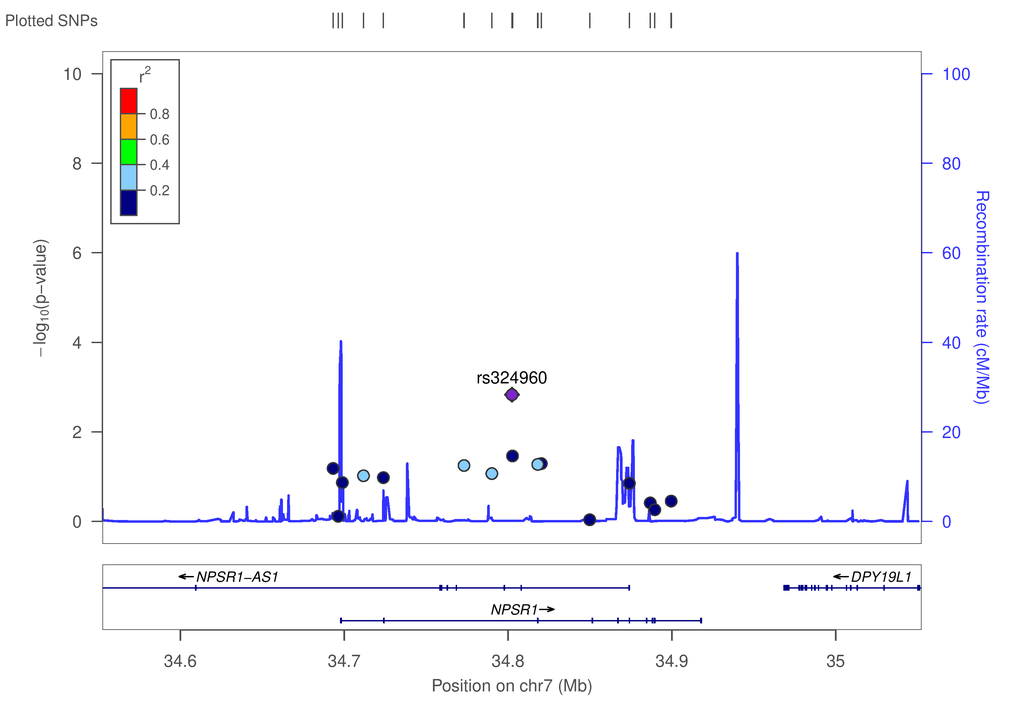

Grafic 2: Manhattan plot centrat en el SNP rs324960

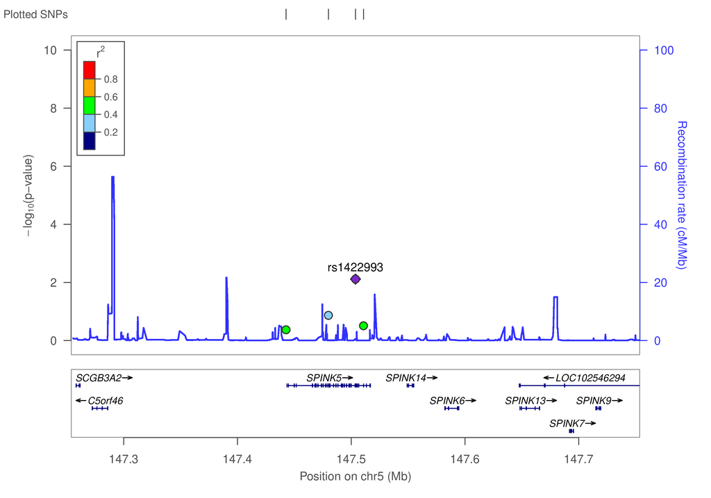

Grafic 3: Manhattan plot centrat en el SNP rs1422993

En els Gràfics 2 i 3, tenim el manhattan plot d’una regió concreta dels cromosomes 7 i 5 respectivament. En l’eix d’ordenades tenim el negatiu del logaritme en base 10 del p-valor no corregit, calculat en la secció 2.5, i que es pot veure en la taula 4 de la secció 2.7. En l’eix d’abscisses, tenim la posició on es troba cada SNP en el cromosoma, en milions de bases (Mb).

En el Gràfic 2, s’ha representat la zona on es troba l’snp amb el p-valor més baix rs324960. Es troba uns dos cops més elevat que la resta, que es mantenen a un nivell inferior a 2. Aquesta distància ens dóna un motiu per arribar a considerar l’snp com a significatiu.

En el Gràfic 3, s’ha representat la zona on es troba el segon snp amb el p-valor més baix rs1422993. El nombre de SNPs és molt baix (quatre) en aquesta zona, no podem extreure les mateixes conclusions que en el Gràfic 2.

# 3. Conclusions

Tot i que no s’han trobat variants genètiques significatives que augmentin els odds de patir asma, s’ha vist que la variant rs324960 pot influir a disminuir els odds de patir asma a l’estar present com a menor homozigot, respecte no estar present, com a menor homozigot.

# ANNEX

El codi d’aquesta entrega es pot trobar a github: cesc1/GAS-example.

- code: Funcions utilitzades en l’entrega.
- main: Document .Rdm amb el respectiu .html entregat.
- data: Dades utilitzades asthma, i taules de dades creades.